# Introduction to Decision Trees

Dr. Lasanthi Watagoda

2026-10-29

```r
# Load necessary libraries
library(rpart)
library(rpart.plot)
```

# Housing Data Set (Regression Tree)

```r
# Create a dataframe
data <- data.frame(
Value = c(300000, 350000, 280000, 500000, 450000, 400000, 380000),
Style = c("Ranch", "Ranch", "Ranch", "Colonial", "Colonial", "CapeCod","Colonial"),
SqFt = c(1600, 1400, 1700, 1800, 2100, 1500, 1900),
Bedrooms = c(3, 2, 3, 4, 3, 2, 3))
```

```r
# Convert categorical variable
data$Style <- factor(data$Style)
```

```r
# Build the Tree
tree_model <- rpart(Value ~ Style + SqFt + Bedrooms, data = data, method = "anova",
control = rpart.control(cp = 0.02, minsplit = 2))
```

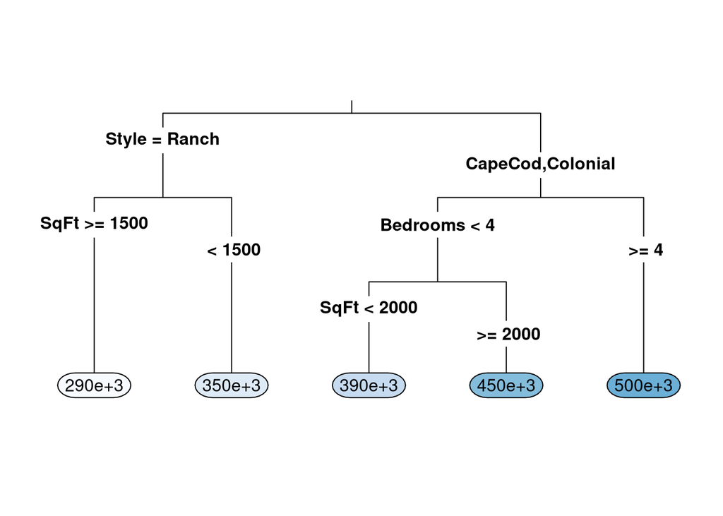

Argument-by-Argument Breakdown for rpart.plot()

| Argument | Meaning | Effect |
| --- | --- | --- |
| tree_model | The fitted model created with rpart(). | Input tree to plot. |
| type = 3 | Controls layout of split and node labels. | Places split labels above branches and node labels inside boxes for readability. |
| extra = 0 | Controls what extra info is displayed in leaf nodes. | Shows only predicted value (for regression) or class (for classification). |
| box.palette = ‘Blues’ | Applies a color gradient from the RColorBrewer palette ‘Blues’. | Darker color = higher predicted value. |
| under = TRUE | Places split condition text under the node box. | Makes the diagram more compact. |
| fallen.leaves = TRUE | Arranges all terminal nodes at the bottom of the plot. | Makes the tree look like a traditional tree with leaves at the bottom. |

```r
# Plot the tree
rpart.plot(tree_model, type = 3, extra = 0, box.palette = "Blues",
under = TRUE, fallen.leaves = TRUE)
```

```r
# prediction for a new house:
predict(tree_model, newdata = data.frame(Style = "CapeCod", SqFt = 1600, Bedrooms = 3))
```

```
##      1
## 390000
```

```r
#To illustrate selecting optimal α.
printcp(tree_model)
```

```
##
## Regression tree:
## rpart(formula = Value ~ Style + SqFt + Bedrooms, data = data,
##     method = "anova", control = rpart.control(cp = 0.02, minsplit = 2))
##
## Variables actually used in tree construction:
## [1] Bedrooms SqFt     Style
##
## Root node error: 3.7e+10/7 = 5285714286
##
## n= 7
##
##         CP nsplit rel error  xerror    xstd
## 1 0.695270      0  1.000000 1.36111 0.49042
## 2 0.164189      1  0.304730 1.04362 0.26396
## 3 0.064865      2  0.140541 0.93716 0.22770
## 4 0.020000      4  0.010811 1.25946 0.39740
```

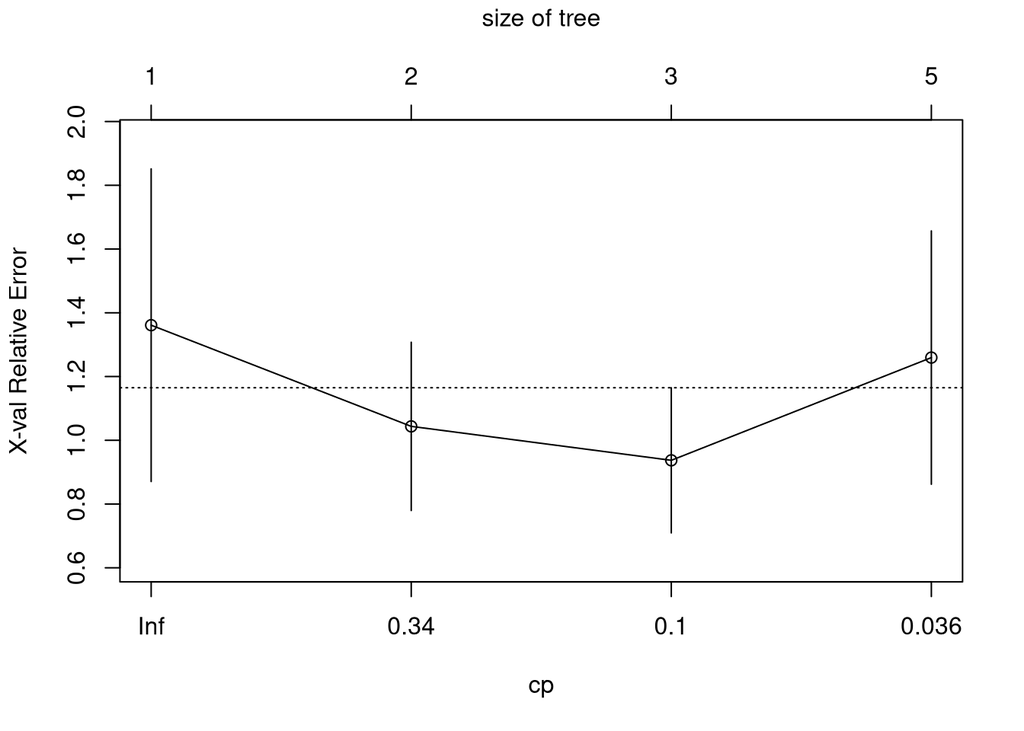

```r
plotcp(tree_model)
```

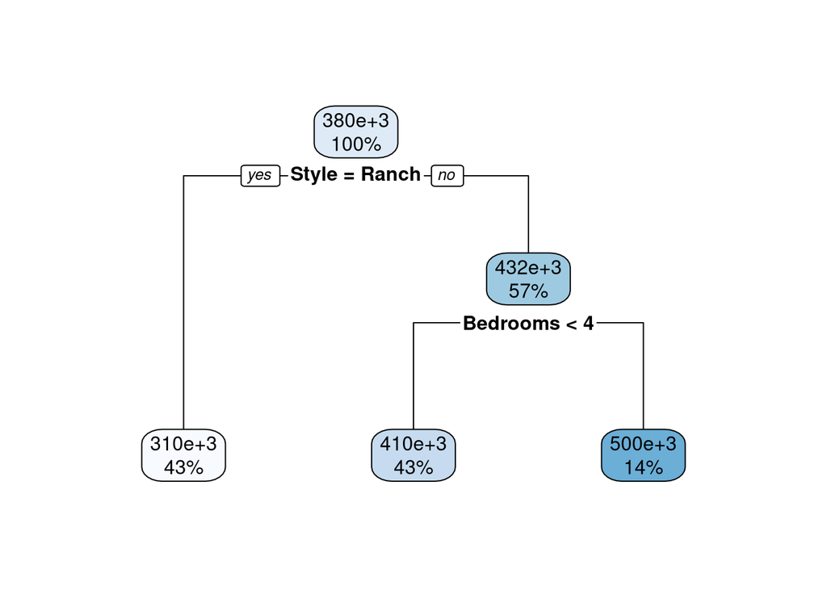

```r
pruned_model <- prune(tree_model, cp = 0.1)
rpart.plot(pruned_model)
```

# IRIS Data set (Classification Tree)

The Iris dataset is a classic and widely used dataset in statistics and machine learning. It contains 150 observations of iris flowers, collected from three different species: Iris setosa, Iris versicolor, and Iris virginica — with 50 samples per species.

Each observation includes four numerical features describing the physical dimensions of the flowers:

- Sepal length (cm)
- Sepal width (cm)
- Petal length (cm)
- Petal width (cm)

The goal of analyses using this dataset is often to classify the species of iris based on these measurements or to explore patterns and relationships among the features. The dataset is well-balanced, easy to visualize, and frequently used for demonstrating data analysis, pattern recognition, and machine learning techniques such as classification and clustering.

```r
# Load libraries
library(rpart)
library(rpart.plot)
```

```r
# Example dataset
head(iris)
```

|  | Sepal.Length | Sepal.Width | Petal.Length | Petal.Width | Species |
| --- | --- | --- | --- | --- | --- |
| 1 | 5.1 | 3.5 | 1.4 | 0.2 | setosa |
| 2 | 4.9 | 3.0 | 1.4 | 0.2 | setosa |
| 3 | 4.7 | 3.2 | 1.3 | 0.2 | setosa |
| 4 | 4.6 | 3.1 | 1.5 | 0.2 | setosa |
| 5 | 5.0 | 3.6 | 1.4 | 0.2 | setosa |
| 6 | 5.4 | 3.9 | 1.7 | 0.4 | setosa |

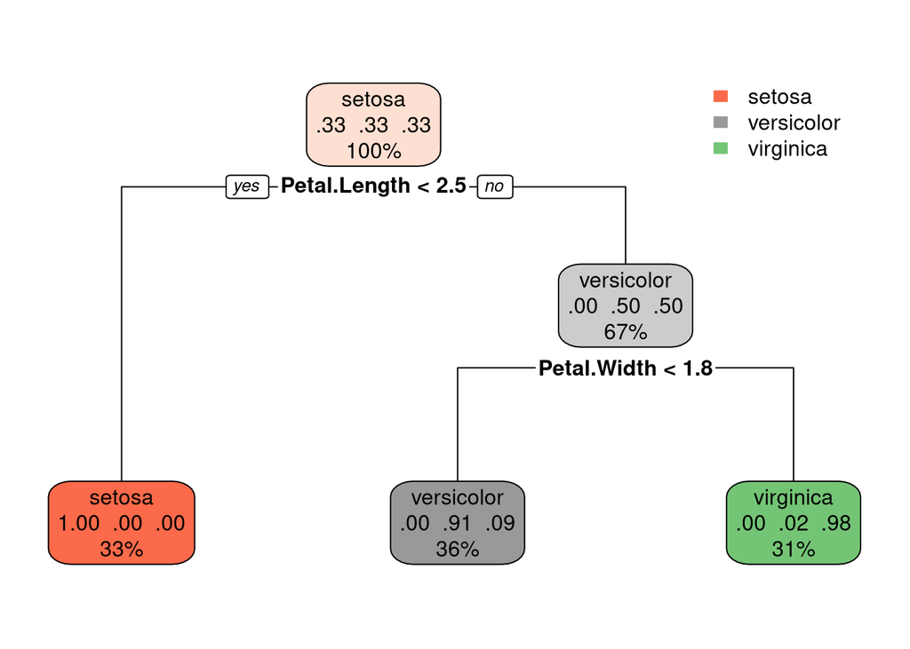

```r
# Build a decision tree to predict Species
tree_model <- rpart(Species ~ ., data = iris, method = "class")


# Visualize the tree
rpart.plot(tree_model)
```

```r
# Predict for a new observation
new_data <- data.frame(Sepal.Length=5.1, Sepal.Width=3.5, Petal.Length=1.4, Petal.Width=0.2)
predict(tree_model, new_data, type="class")
```

```
##      1
## setosa
## Levels: setosa versicolor virginica
```

# Optimizing Classification Trees

## Classification Error Rate

Recall: The Classification Error Rate measures the proportion of observations that are incorrectly classified in a node.

$$E=1-\max_k(p_k)$$

where $p_k$ is the proportion of observations belonging to class $k$ in the node.

A smaller classification error rate indicates a purer node. A value of zero means all observations belong to the same class.

```r
# Calculate classification error rate at each node.

node_results <- data.frame(
  Node = rownames(tree_model$frame),
  Observations = tree_model$frame$n,
  Misclassified = tree_model$frame$dev,
  Classification_Error = tree_model$frame$dev / tree_model$frame$n
)

knitr::kable(node_results, digits = 4)
```

| Node | Observations | Misclassified | Classification_Error |
| --- | --- | --- | --- |
| 1 | 150 | 100 | 0.6667 |
| 2 | 50 | 0 | 0.0000 |
| 3 | 100 | 50 | 0.5000 |
| 6 | 54 | 5 | 0.0926 |
| 7 | 46 | 1 | 0.0217 |

## Gini index and Cross Entropy Trees: Fit two classification trees using the Iris data

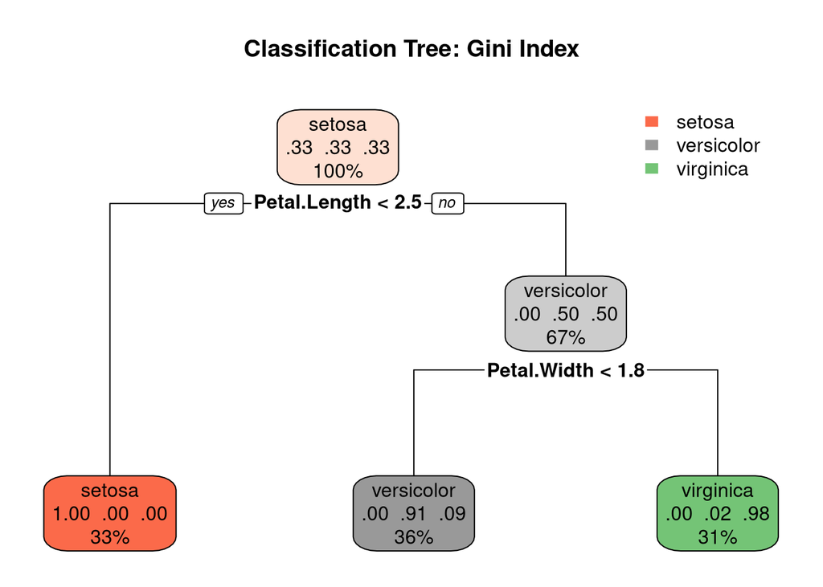

```r
library(rpart)
library(rpart.plot)

data(iris)

# Classification tree using Gini index
tree_gini <- rpart(Species ~ .,data = iris,method = "class",parms = list(split = "gini"),control = rpart.control(cp = 0.01)
)

# Classification tree using Cross-Entropy
tree_entropy <- rpart(
  Species ~ .,
  data = iris,
  method = "class",
  parms = list(split = "information"),
  control = rpart.control(cp = 0.01) # Use information for splitting when you are using cross entropy
)

# Plot the Gini tree
rpart.plot(tree_gini,
           type = 2,
           extra = 104,
           fallen.leaves = TRUE,
           main = "Classification Tree: Gini Index")
```

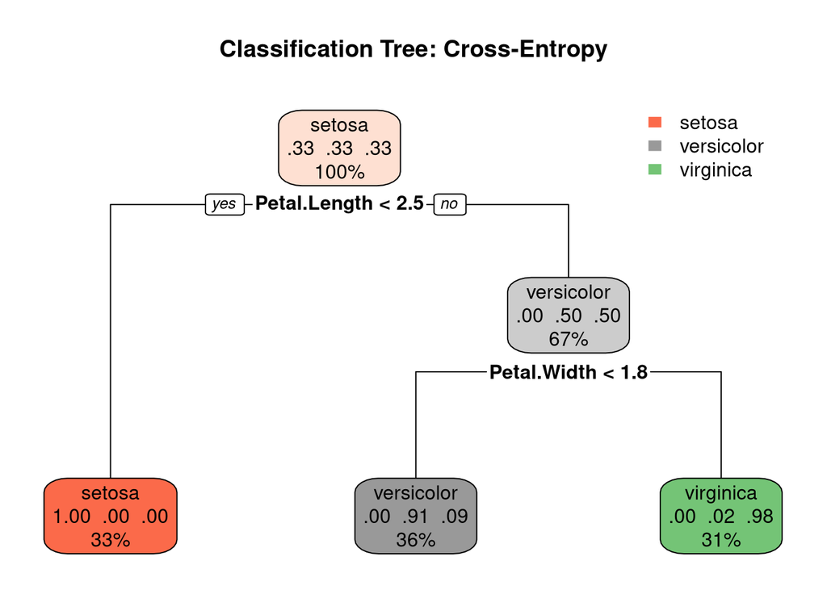

```r
# Plot the Cross-Entropy tree
rpart.plot(tree_entropy,
           type = 2,
           extra = 104,
           fallen.leaves = TRUE,
           main = "Classification Tree: Cross-Entropy")
```

### Calculate Gini index and cross-entropy manually

```r
# Class probabilities
class_probs <- prop.table(table(iris$Species))
class_probs
```

```
##
##     setosa versicolor  virginica
##  0.3333333  0.3333333  0.3333333
```

```r
# Gini index
gini <- 1 - sum(class_probs^2)
gini
```

```
## [1] 0.6666667
```

```r
# Cross-entropy (natural logarithm)
entropy <- -sum(class_probs * log(class_probs))
entropy
```

```
## [1] 1.098612
```

### Demonstrate how a split reduces impurity

Consider a simple split using `Petal.Length`.

```r
# Now consider a simple split using Petal.Length.

# Divide observations into two groups
left_node <- subset(iris, Petal.Length < 2.5)
right_node <- subset(iris, Petal.Length >= 2.5)

# Examine species counts
table(left_node$Species)
```

```
##
##     setosa versicolor  virginica
##         50          0          0
```

```r
table(right_node$Species)
```

```
##
##     setosa versicolor  virginica
##          0         50         50
```

The first group contains all 50 Setosa flowers. The second group contains the remaining 100 flowers.

### Calculate impurity for each group:

```r
# Functions for Gini and cross-entropy
gini_index <- function(y) {
  p <- prop.table(table(y))
  1 - sum(p^2)
}

cross_entropy <- function(y) {
  p <- prop.table(table(y))
  -sum(p[p > 0] * log(p[p > 0]))
}

# Calculate impurity in each node
gini_index(left_node$Species)
```

```
## [1] 0
```

```r
gini_index(right_node$Species)
```

```
## [1] 0.5
```

```r
cross_entropy(left_node$Species)
```

```
## [1] 0
```

```r
cross_entropy(right_node$Species)
```

```
## [1] 0.6931472
```

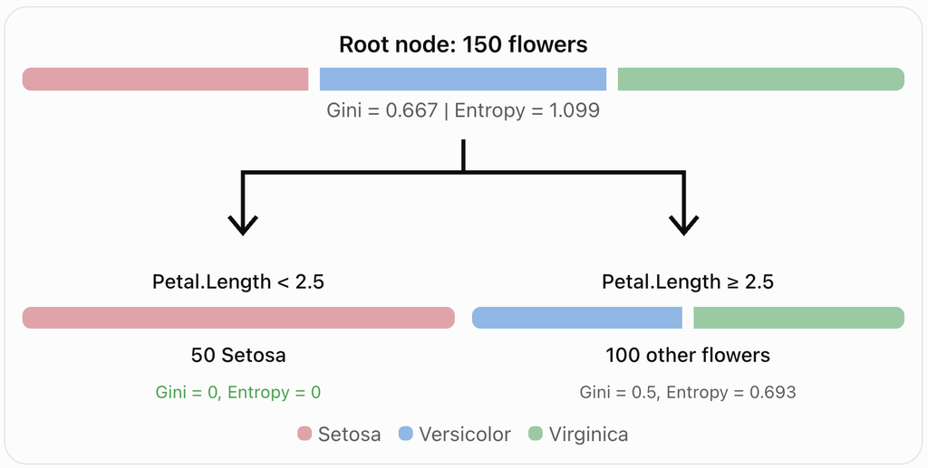

This split separates Setosa perfectly, so the left node has zero impurity. The right node still contains two species in equal proportions.

### Calculate improvement in impurity

Why the tree considers this split useful?

```r
# Weighted Gini after splitting
weighted_gini <-
  (50/150) * gini_index(left_node$Species) +
  (100/150) * gini_index(right_node$Species)

# Gini improvement
gini_improvement <-
  gini_index(iris$Species) - weighted_gini

# Weighted cross-entropy after splitting
weighted_entropy <-
  (50/150) * cross_entropy(left_node$Species) +
  (100/150) * cross_entropy(right_node$Species)

# Information gain
information_gain <-
  cross_entropy(iris$Species) - weighted_entropy

gini_improvement
```

```
## [1] 0.3333333
```

```r
information_gain
```

```
## [1] 0.6365142
```

| Measure | Before Split | After Split | Reduction |
| --- | --- | --- | --- |
| Gini Index | 0.6667 | 0.3333 | 0.3333 |
| Cross-Entropy | 1.0986 | 0.4621 | 0.6365 |

A classification tree searches for splits that maximize the reduction in impurity. Both Gini and cross-entropy reward splits that produce purer child nodes, although they can sometimes prefer different splits.

## Residual Mean Deviance

We can use the same iris dataset and the same split (Petal.Length < 2.5) to calculate Residual Mean Deviance for classification trees.

For classification trees, the formula from our lecture is:

$$\text{Residual Mean Deviance} =
-\frac{1}{n-|T|}\sum_{m=1}^{|T|}\sum_{k=1}^{K}n_{mk}\ln(p_{mk})$$

```r
# Load iris data
data(iris)

# Use the same split
left_node <- subset(iris, Petal.Length < 2.5)
right_node <- subset(iris, Petal.Length >= 2.5)

# Function to calculate node deviance
node_deviance <- function(y) {
  counts <- table(y)
  p <- counts / sum(counts) # Only include nonzero probabilities
  -sum(counts[p > 0] * log(p[p > 0]))
}

# Deviance before splitting
deviance_before <- node_deviance(iris$Species)

# Deviance after splitting
deviance_after <-
  node_deviance(left_node$Species) +
  node_deviance(right_node$Species)

# Number of observations
n <- nrow(iris)

# Residual Mean Deviance
rmd_before <- deviance_before / (n - 1)
rmd_after <- deviance_after / (n - 2)

# Create comparison table
results_rmd <- data.frame(
  Model = c("Before Split", "After Split"),
  Terminal_Nodes = c(1, 2),
  Deviance = c(deviance_before, deviance_after),
  Residual_Mean_Deviance = c(rmd_before, rmd_after)
)

# Display results
knitr::kable(
  results_rmd,
  digits = 4,
  col.names = c("Model", "Terminal Nodes",
                "Deviance", "Residual Mean Deviance")
)
```

| Model | Terminal Nodes | Deviance | Residual Mean Deviance |
| --- | --- | --- | --- |
| Before Split | 1 | 164.7918 | 1.1060 |
| After Split | 2 | 69.3147 | 0.4683 |

Before splitting, all 150 observations are in one node, and the Residual Mean Deviance is approximately 1.1060.

After splitting at `Petal.Length = 2.5`, the observations are divided into two groups. The Residual Mean Deviance decreases to approximately 0.4683.

This indicates that the split produces more homogeneous groups and improves the fit according to this measure.

**Connection to your previous example**: Cross-entropy measures the impurity within a node, while Residual Mean Deviance combines the cross-entropy contributions across terminal nodes and adjusts by $n-|T|$.

**One important distinction**: this is a manually calculated entropy-based residual mean deviance. The dev column in rpart classification-tree output uses a different definition (misclassification counts), so its values will not match these calculations.

Residual Mean Deviance can be used to compare different decision trees fitted to the same dataset.

The general idea is: - Smaller Residual Mean Deviance indicates a better fit. - Larger Residual Mean Deviance indicates a poorer fit.

For example, using our iris dataset:

| Tree | Terminal Nodes | Residual Mean Deviance |
| --- | --- | --- |
| Tree 1 (No split) | 1 | 1.1060 |
| Tree 2 (One split) | 2 | 0.4683 |

Here, Tree 2 fits the training data better because it has a smaller Residual Mean Deviance.

**One important distinction**

- Gini index and cross-entropy: Primarily used to decide where to split a classification tree.
- Residual Mean Deviance: Used to assess and compare the fit of trees after they have been constructed.

However, *a smaller training Residual Mean Deviance does not necessarily mean a better tree* for prediction. A complex tree may fit the training data very well but overfit.

For choosing the best tree, we generally prefer *cross-validation error* or *test-set performance*, particularly when comparing trees with different numbers of terminal nodes.

**Let’s compare two different splits of the iris dataset and see which one produces a smaller Residual Mean Deviance.**

We’ll use:

- Tree 2: `Petal.Length < 2.5` (our previous split)
- Tree 3: `Petal.Width < 1.5` (a different split)

Both trees have two terminal nodes, so this is a straightforward comparison.

```r
data(iris)

# Function to calculate node deviance
node_deviance <- function(y) {
  counts <- table(y)
  p <- counts / sum(counts)
  -sum(counts[p > 0] * log(p[p > 0]))
}

# Function to calculate Residual Mean Deviance for a split
calculate_rmd <- function(data, variable, cutoff) {

  left_node <- data[data[[variable]] < cutoff, ]
  right_node <- data[data[[variable]] >= cutoff, ]

  n <- nrow(data)
  T <- 2  # Two terminal nodes

  total_deviance <-
    node_deviance(left_node$Species) +
    node_deviance(right_node$Species)

  total_deviance / (n - T)
}

# Tree 2: Split using Petal.Length
rmd_tree2 <- calculate_rmd(iris, "Petal.Length", 2.5)

# Tree 3: Split using Petal.Width
rmd_tree3 <- calculate_rmd(iris, "Petal.Width", 1.5)

# Compare the trees
comparison <- data.frame(
  Tree = c("Tree 2", "Tree 3"),
  Split = c("Petal.Length < 2.5",
            "Petal.Width < 1.5"),
  Terminal_Nodes = c(2, 2),
  Residual_Mean_Deviance = c(rmd_tree2, rmd_tree3)
)

knitr::kable(comparison, digits = 4)
```

| Tree | Split | Terminal_Nodes | Residual_Mean_Deviance |
| --- | --- | --- | --- |
| Tree 2 | Petal.Length < 2.5 | 2 | 0.4683 |
| Tree 3 | Petal.Width < 1.5 | 2 | 0.6614 |

Now, Examine the splits

It’s also helpful to see which species are in each terminal node.

```r
# Tree 2
table(
  Node = ifelse(iris$Petal.Length < 2.5, "Left", "Right"),
  Species = iris$Species
)
```

```
##        Species
## Node    setosa versicolor virginica
##   Left      50          0         0
##   Right      0         50        50
```

```r
# Tree 3
table(
  Node = ifelse(iris$Petal.Width < 1.5, "Left", "Right"),
  Species = iris$Species
)
```

```
##        Species
## Node    setosa versicolor virginica
##   Left      50         35         1
##   Right      0         15        49
```

The split with the smaller Residual Mean Deviance produces purer terminal nodes and fits these training observations better according to the entropy-based measure.

Because both trees have the same number of terminal nodes, the comparison is particularly easy to interpret.

Which split would you choose based on Residual Mean Deviance? Does the composition of the terminal nodes explain your choice?

# Bagging

We can use the `ipred` package for bagging classification trees.

```r
# Load required libraries
library(ipred)
library(ggplot2)

# Use the iris dataset
data(iris)

# Fit a bagging model
set.seed(123)
bag_model <- bagging(Species ~ ., data = iris, nbagg = 50)

# Predict and evaluate accuracy
pred_bag <- predict(bag_model, iris)
pred_bag
```

```
##   [1] setosa     setosa     setosa     setosa     setosa     setosa
##   [7] setosa     setosa     setosa     setosa     setosa     setosa
##  [13] setosa     setosa     setosa     setosa     setosa     setosa
##  [19] setosa     setosa     setosa     setosa     setosa     setosa
##  [25] setosa     setosa     setosa     setosa     setosa     setosa
##  [31] setosa     setosa     setosa     setosa     setosa     setosa
##  [37] setosa     setosa     setosa     setosa     setosa     setosa
##  [43] setosa     setosa     setosa     setosa     setosa     setosa
##  [49] setosa     setosa     versicolor versicolor versicolor versicolor
##  [55] versicolor versicolor versicolor versicolor versicolor versicolor
##  [61] versicolor versicolor versicolor versicolor versicolor versicolor
##  [67] versicolor versicolor versicolor versicolor versicolor versicolor
##  [73] versicolor versicolor versicolor versicolor versicolor versicolor
##  [79] versicolor versicolor versicolor versicolor versicolor versicolor
##  [85] versicolor versicolor versicolor versicolor versicolor versicolor
##  [91] versicolor versicolor versicolor versicolor versicolor versicolor
##  [97] versicolor versicolor versicolor versicolor virginica  virginica
## [103] virginica  virginica  virginica  virginica  virginica  virginica
## [109] virginica  virginica  virginica  virginica  virginica  virginica
## [115] virginica  virginica  virginica  virginica  virginica  virginica
## [121] virginica  virginica  virginica  virginica  virginica  virginica
## [127] virginica  virginica  virginica  virginica  virginica  virginica
## [133] virginica  virginica  virginica  virginica  virginica  virginica
## [139] virginica  virginica  virginica  virginica  virginica  virginica
## [145] virginica  virginica  virginica  virginica  virginica  virginica
## Levels: setosa versicolor virginica
```

```r
pred_bag == iris$Species
```

```
##   [1] TRUE TRUE TRUE TRUE TRUE TRUE TRUE TRUE TRUE TRUE TRUE TRUE TRUE TRUE TRUE
##  [16] TRUE TRUE TRUE TRUE TRUE TRUE TRUE TRUE TRUE TRUE TRUE TRUE TRUE TRUE TRUE
##  [31] TRUE TRUE TRUE TRUE TRUE TRUE TRUE TRUE TRUE TRUE TRUE TRUE TRUE TRUE TRUE
##  [46] TRUE TRUE TRUE TRUE TRUE TRUE TRUE TRUE TRUE TRUE TRUE TRUE TRUE TRUE TRUE
##  [61] TRUE TRUE TRUE TRUE TRUE TRUE TRUE TRUE TRUE TRUE TRUE TRUE TRUE TRUE TRUE
##  [76] TRUE TRUE TRUE TRUE TRUE TRUE TRUE TRUE TRUE TRUE TRUE TRUE TRUE TRUE TRUE
##  [91] TRUE TRUE TRUE TRUE TRUE TRUE TRUE TRUE TRUE TRUE TRUE TRUE TRUE TRUE TRUE
## [106] TRUE TRUE TRUE TRUE TRUE TRUE TRUE TRUE TRUE TRUE TRUE TRUE TRUE TRUE TRUE
## [121] TRUE TRUE TRUE TRUE TRUE TRUE TRUE TRUE TRUE TRUE TRUE TRUE TRUE TRUE TRUE
## [136] TRUE TRUE TRUE TRUE TRUE TRUE TRUE TRUE TRUE TRUE TRUE TRUE TRUE TRUE TRUE
```

```r
mean(pred_bag == iris$Species)
```

```
## [1] 1
```

```r
table(Actual = iris$Species, Predicted = pred_bag)
```

```
##             Predicted
## Actual       setosa versicolor virginica
##   setosa         50          0         0
##   versicolor      0         50         0
##   virginica       0          0        50
```

# Random Forest

Use `randomForest` directly — it’s the most popular ensemble method.

```r
library(randomForest)

set.seed(123)
rf_model <- randomForest(Species ~ ., data = iris, ntree = 100, importance = TRUE)

# Model summary
print(rf_model)
```

```
##
## Call:
##  randomForest(formula = Species ~ ., data = iris, ntree = 100,      importance = TRUE)
##                Type of random forest: classification
##                      Number of trees: 100
## No. of variables tried at each split: 2
##
##         OOB estimate of  error rate: 4.67%
## Confusion matrix:
##            setosa versicolor virginica class.error
## setosa         50          0         0        0.00
## versicolor      0         46         4        0.08
## virginica       0          3        47        0.06
```

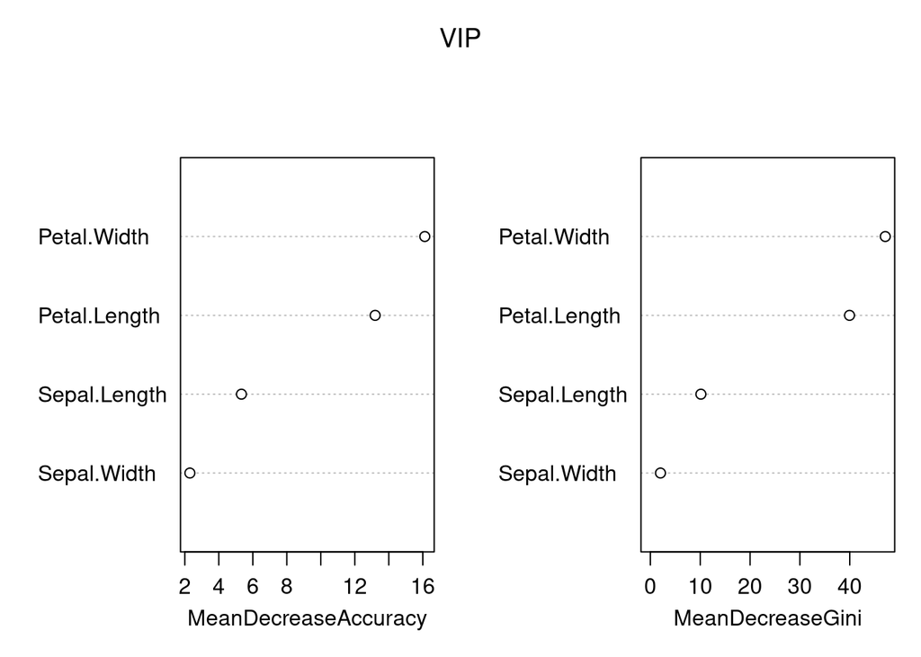

```r
# Variable importance (randomForest style)


varImpPlot(rf_model, main = "VIP") # Default
```

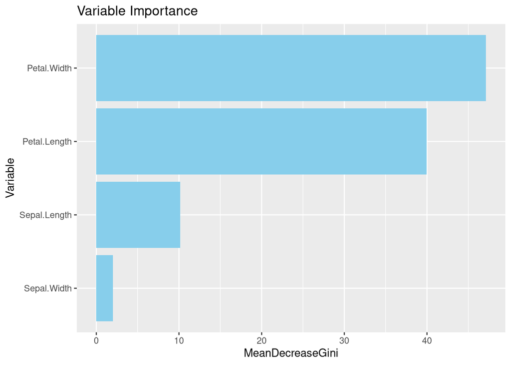

```r
# Fancy
importance_df <- data.frame(Variable = rownames(importance(rf_model)),
                            Importance = importance(rf_model)[,5])

# Plot variable importance
ggplot(importance_df, aes(x = reorder(Variable, Importance), y = Importance)) +
  geom_bar(stat = "identity", fill = "skyblue") +
  coord_flip() +
  labs(title = "Variable Importance ",
       x = "Variable", y = "MeanDecreaseGini")
```

For classification problems (like Species in the iris dataset):

MeanDecreaseAccuracy – how much model accuracy drops when the variable’s values are randomly permuted.

MeanDecreaseGini – how much each variable reduces node impurity (Gini index) across the forest.

For regression problems:

%IncMSE – percent increase in mean squared error when the variable is permuted.

IncNodePurity – total decrease in residual sum of squares (RSS) from splits involving that variable.

# Boosting

We’ll use `gbm` (gradient boosting machine) for a simple demonstration.

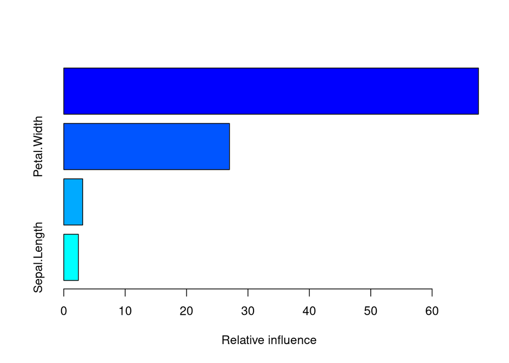

|  | var | rel.inf |
| --- | --- | --- |
| Petal.Length | Petal.Length | 67.547717 |
| Petal.Width | Petal.Width | 26.995234 |
| Sepal.Width | Sepal.Width | 3.079212 |
| Sepal.Length | Sepal.Length | 2.377837 |

```r
library(gbm)

set.seed(123)
# gbm requires numeric target, so we convert
iris_boost <- iris
iris_boost$Species <- as.numeric(iris$Species) - 1

boost_model <- gbm(Species ~ ., data = iris_boost,
                   distribution = "multinomial",
                   n.trees = 200,
                   interaction.depth = 3,
                   shrinkage = 0.1,
                   cv.folds = 5)

# Summary gives variable importance
summary(boost_model)
```

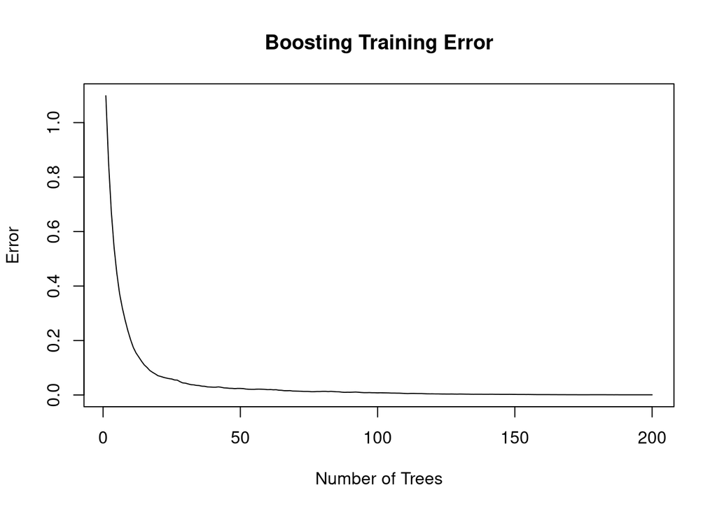

```r
# Plot training loss
plot(boost_model$train.error, type = "l",
     main = "Boosting Training Error",
     xlab = "Number of Trees", ylab = "Error")
```

## Full R Demo — Bagging, Random Forest, and Boosting (with Visualization)

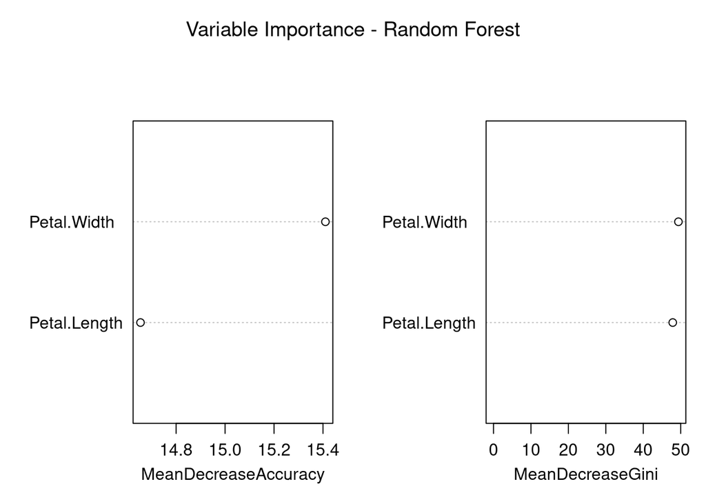

```r
# =========================================
# Ensemble Methods Demo with Visualization
# =========================================

# Load required libraries
library(ipred)
library(randomForest)
library(gbm)
library(ggplot2)
library(dplyr)

# Prepare data
data(iris)
iris2 <- iris[, c("Petal.Length", "Petal.Width", "Species")]

# Create a grid for plotting decision boundaries
make_grid <- function(data, n = 200) {
  x1 <- seq(min(data$Petal.Length), max(data$Petal.Length), length.out = n)
  x2 <- seq(min(data$Petal.Width),  max(data$Petal.Width),  length.out = n)
  grid <- expand.grid(Petal.Length = x1, Petal.Width = x2)
  return(grid)
}

grid <- make_grid(iris2)

# ==============================
# 1️⃣ Bagging
# ==============================
set.seed(123)
bag_model <- bagging(Species ~ ., data = iris2, nbagg = 50)
grid$pred_bag <- predict(bag_model, grid)

# ==============================
# 2️⃣ Random Forest
# ==============================
set.seed(123)
rf_model <- randomForest(Species ~ ., data = iris2, ntree = 100, importance = TRUE)
grid$pred_rf <- predict(rf_model, grid)

# Variable importance plot
varImpPlot(rf_model, main = "Variable Importance - Random Forest")
```

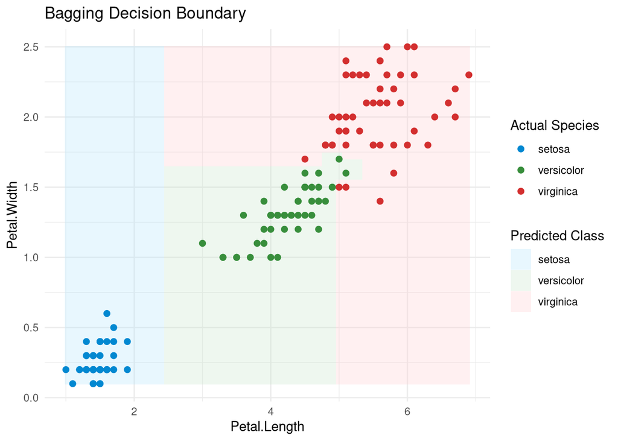

```r
# ==============================
# 3️⃣ Boosting
# ==============================
iris_boost <- iris2
iris_boost$Species <- as.numeric(iris_boost$Species) - 1  # convert to numeric

boost_model <- gbm(Species ~ ., data = iris_boost,
                   distribution = "multinomial",
                   n.trees = 200,
                   interaction.depth = 3,
                   shrinkage = 0.1,
                   cv.folds = 5,
                   verbose = FALSE)

# Predict on grid (boosting)
boost_pred <- predict(boost_model, newdata = grid, n.trees = 200, type = "response")
grid$pred_boost <- factor(apply(boost_pred, 1, which.max) - 1,
                          labels = levels(iris$Species))

# ==============================
# ✨ Visualization
# ==============================
plot_decision <- function(grid, model_col, title) {
  ggplot(grid, aes(Petal.Length, Petal.Width)) +
    geom_tile(aes(fill = !!sym(model_col)), alpha = 0.3) +
    geom_point(data = iris2, aes(color = Species), size = 2) +
    scale_fill_manual(values = c("#B3E5FC", "#C8E6C9", "#FFCDD2")) +
    scale_color_manual(values = c("#0288D1", "#388E3C", "#D32F2F")) +
    labs(title = title, fill = "Predicted Class", color = "Actual Species") +
    theme_minimal()
}

p1 <- plot_decision(grid, "pred_bag", "Bagging Decision Boundary")
p2 <- plot_decision(grid, "pred_rf", "Random Forest Decision Boundary")
p3 <- plot_decision(grid, "pred_boost", "Boosting Decision Boundary")

# Display plots
p1
```

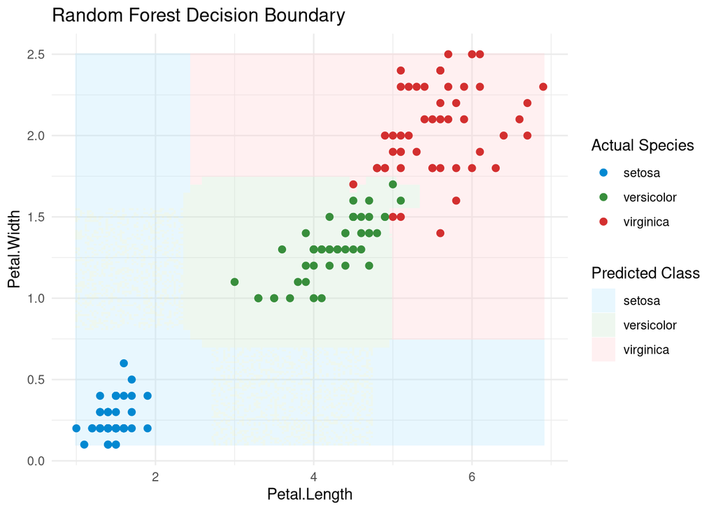

```r
p2
```

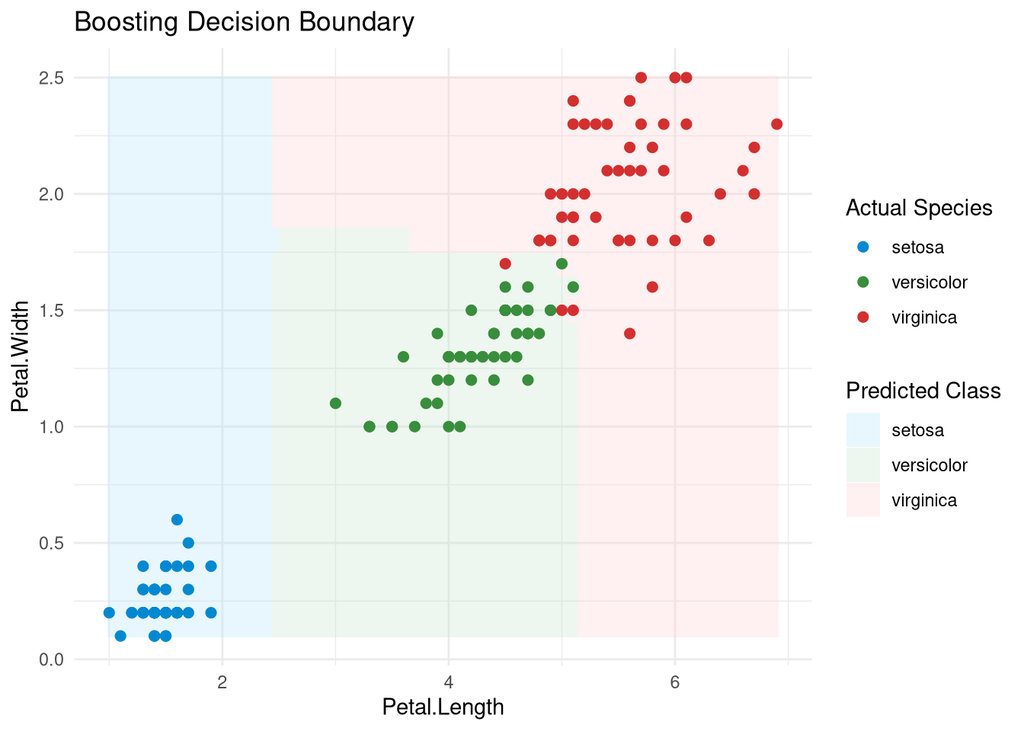

[output not shown]

```r
p3
```

Summary Points

- Bagging reduces variance by averaging multiple trees.
- Random Forest improves bagging by introducing randomness in feature selection.
- Boosting builds trees sequentially, each correcting errors of the previous ones.

## Example - Comparing models - Regression setting

```r
library(rpart)
library(ipred)
library(randomForest)
library(gbm)
library(ggplot2)

# ========================================
# 1. Prepare the data
# ========================================

data(airquality)
aq <- na.omit(airquality)

set.seed(123)
train_id <- sample(seq_len(nrow(aq)),
                   size = floor(0.7 * nrow(aq)))

train <- aq[train_id, ]
test <- aq[-train_id, ]

# ========================================
# 2. Single Regression Tree
# ========================================

tree_model <- rpart(
  Ozone ~ .,
  data = train,
  method = "anova",
  control = rpart.control(cp = 0.01)
)

pred_tree <- predict(tree_model, newdata = test)

# ========================================
# 3. Bagging
# ========================================

set.seed(123)
bag_model <- bagging(
  Ozone ~ .,
  data = train,
  nbagg = 200
)

pred_bag <- predict(bag_model, newdata = test)

# ========================================
# 4. Random Forest
# ========================================

set.seed(123)
rf_model <- randomForest(
  Ozone ~ .,
  data = train,
  ntree = 200
)

pred_rf <- predict(rf_model, newdata = test)

# ========================================
# 5. Boosting
# ========================================

set.seed(123)
boost_model <- gbm(
  Ozone ~ .,
  data = train,
  distribution = "gaussian",
  n.trees = 500,
  interaction.depth = 2,
  shrinkage = 0.05,
  n.minobsinnode = 5,
  cv.folds = 5,
  verbose = FALSE
)

best_B <- gbm.perf(boost_model,
                   method = "cv",
                   plot.it = FALSE)

pred_boost <- predict(
  boost_model,
  newdata = test,
  n.trees = best_B
)

# ========================================
# 6. Evaluation functions
# ========================================

RMSE <- function(actual, predicted) {
  sqrt(mean((actual - predicted)^2))
}

MAE <- function(actual, predicted) {
  mean(abs(actual - predicted))
}

R2 <- function(actual, predicted) {
  1 - sum((actual - predicted)^2) /
      sum((actual - mean(actual))^2)
}

# ========================================
# 7. Compare all four models
# ========================================

results <- data.frame(
  Model = c("Single Tree", "Bagging",
            "Random Forest", "Boosting"),

  RMSE = c(
    RMSE(test$Ozone, pred_tree),
    RMSE(test$Ozone, pred_bag),
    RMSE(test$Ozone, pred_rf),
    RMSE(test$Ozone, pred_boost)
  ),

  MAE = c(
    MAE(test$Ozone, pred_tree),
    MAE(test$Ozone, pred_bag),
    MAE(test$Ozone, pred_rf),
    MAE(test$Ozone, pred_boost)
  ),

  R2 = c(
    R2(test$Ozone, pred_tree),
    R2(test$Ozone, pred_bag),
    R2(test$Ozone, pred_rf),
    R2(test$Ozone, pred_boost)
  )
)

# Rank by lowest RMSE
results <- results[order(results$RMSE), ]

print(results)
```

```
##           Model     RMSE      MAE        R2
## 3 Random Forest 17.14800 14.04382 0.6247276
## 4      Boosting 18.82400 15.37380 0.5477867
## 2       Bagging 19.50127 16.03062 0.5146606
## 1   Single Tree 22.17186 17.38770 0.3726298
```

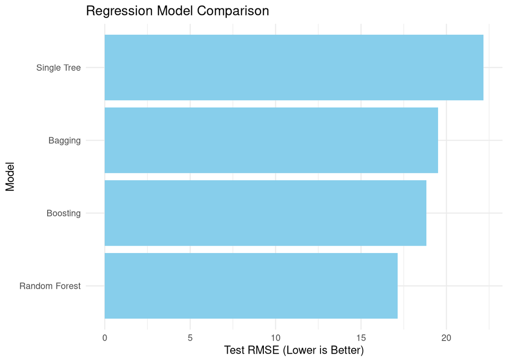

```r
# ========================================
# 8. Visual comparison
# ========================================

ggplot(results,
       aes(x = reorder(Model, RMSE),
           y = RMSE)) +
  geom_col(fill = "skyblue") +
  coord_flip() +
  labs(
    title = "Regression Model Comparison",
    x = "Model",
    y = "Test RMSE (Lower is Better)"
  ) +
  theme_minimal()
```

## Comparing models - Classification setting

Which method best predicts diabetes status: a single tree, bagging, random forest, or boosting?

```r
# ==========================================
# Classification: Comparing Four Tree Models
# Pima Diabetes Dataset
# ==========================================

library(MASS)
```

```r
library(rpart)
library(ipred)
library(randomForest)
library(gbm)
library(ggplot2)

# ==========================================
# 1. Load training and test datasets
# ==========================================

data(Pima.tr)
data(Pima.te)

train <- Pima.tr
test  <- Pima.te

# Explore the data
head(train)
```

|  | npreg | glu | bp | skin | bmi | ped | age | type |
| --- | --- | --- | --- | --- | --- | --- | --- | --- |
| 1 | 5 | 86 | 68 | 28 | 30.2 | 0.364 | 24 | No |
| 2 | 7 | 195 | 70 | 33 | 25.1 | 0.163 | 55 | Yes |
| 3 | 5 | 77 | 82 | 41 | 35.8 | 0.156 | 35 | No |
| 4 | 0 | 165 | 76 | 43 | 47.9 | 0.259 | 26 | No |
| 5 | 0 | 107 | 60 | 25 | 26.4 | 0.133 | 23 | No |
| 6 | 5 | 97 | 76 | 27 | 35.6 | 0.378 | 52 | Yes |

```r
table(train$type)
```

```
##
##  No Yes
## 132  68
```

```r
# ==========================================
# 2. Single Decision Tree
# ==========================================

set.seed(123)

tree_model <- rpart(
  type ~ .,
  data = train,
  method = "class",
  control = rpart.control(cp = 0.01)
)

pred_tree <- predict(
  tree_model, newdata = test, type = "class"
)

# ==========================================
# 3. Bagging
# ==========================================

set.seed(123)

bag_model <- bagging(
  type ~ .,
  data = train,
  nbagg = 200
)

pred_bag <- predict(bag_model, newdata = test)

# ==========================================
# 4. Random Forest
# ==========================================

set.seed(123)

rf_model <- randomForest(
  type ~ .,
  data = train,
  ntree = 200,
  importance = TRUE
)

pred_rf <- predict(rf_model, newdata = test)

# ==========================================
# 5. Boosting
# ==========================================

train_boost <- train
train_boost$type <- as.numeric(train$type == "Yes")

set.seed(123)

boost_model <- gbm(
  type ~ .,
  data = train_boost,
  distribution = "bernoulli",
  n.trees = 500,
  interaction.depth = 2,
  shrinkage = 0.05,
  n.minobsinnode = 5,
  cv.folds = 5,
  verbose = FALSE
)

# Select optimal number of trees
best_B <- gbm.perf(
  boost_model, method = "cv", plot.it = FALSE
)

# Predict probabilities
boost_prob <- predict(
  boost_model,
  newdata = test,
  n.trees = best_B,
  type = "response"
)

# Convert probabilities to class labels
pred_boost <- factor(
  ifelse(boost_prob >= 0.5, "Yes", "No"),
  levels = levels(test$type)
)

# ==========================================
# 6. Compare the models
# ==========================================

accuracy <- function(pred) {
  mean(pred == test$type)
}

sensitivity <- function(pred) {
  sum(pred == "Yes" & test$type == "Yes") /
    sum(test$type == "Yes")
}

results <- data.frame(
  Model = c("Single Tree", "Bagging",
            "Random Forest", "Boosting"),
  Accuracy = c(
    accuracy(pred_tree),
    accuracy(pred_bag),
    accuracy(pred_rf),
    accuracy(pred_boost)
  ),
  Sensitivity = c(
    sensitivity(pred_tree),
    sensitivity(pred_bag),
    sensitivity(pred_rf),
    sensitivity(pred_boost)
  )
)

results$ErrorRate <- 1 - results$Accuracy

# Rank by accuracy
results <- results[order(-results$Accuracy), ]

print(results)
```

```
##           Model  Accuracy Sensitivity ErrorRate
## 4      Boosting 0.7801205   0.5045872 0.2198795
## 3 Random Forest 0.7650602   0.5688073 0.2349398
## 2       Bagging 0.7439759   0.5963303 0.2560241
## 1   Single Tree 0.7319277   0.5596330 0.2680723
```

```r
# ==========================================
# 7. Confusion matrices
# ==========================================

table(Actual = test$type, Predicted = pred_tree)
```

```
##       Predicted
## Actual  No Yes
##    No  182  41
##    Yes  48  61
```

```r
table(Actual = test$type, Predicted = pred_bag)
```

```
##       Predicted
## Actual  No Yes
##    No  182  41
##    Yes  44  65
```

```r
table(Actual = test$type, Predicted = pred_rf)
```

```
##       Predicted
## Actual  No Yes
##    No  192  31
##    Yes  47  62
```

```r
table(Actual = test$type, Predicted = pred_boost)
```

```
##       Predicted
## Actual  No Yes
##    No  204  19
##    Yes  54  55
```

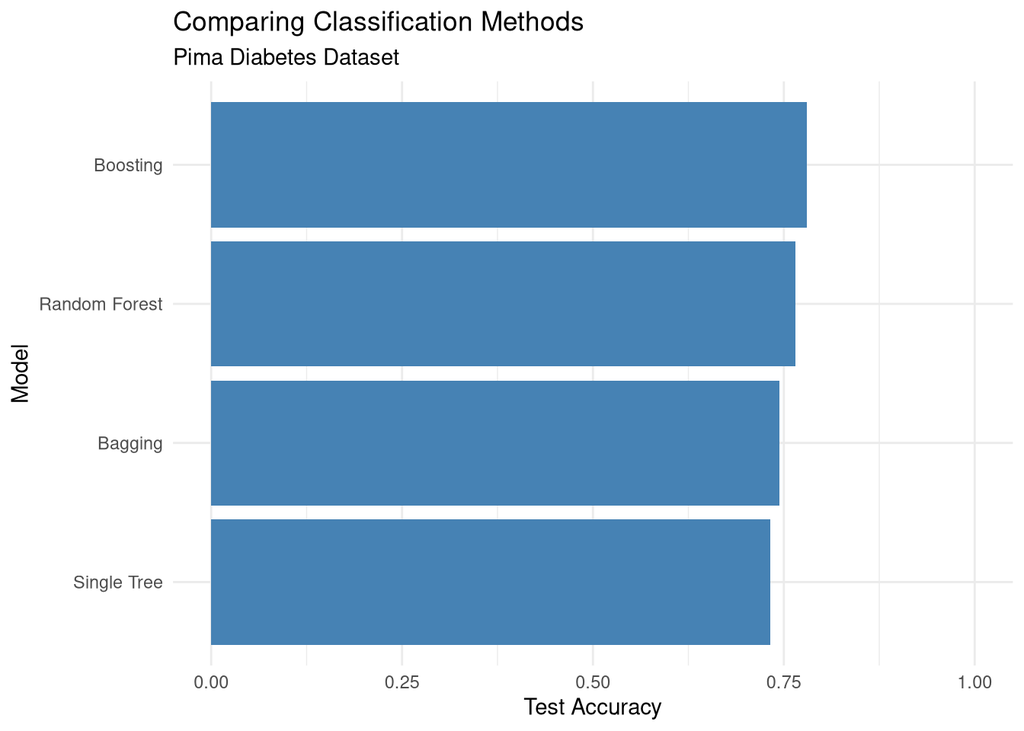

```r
# ==========================================
# 8. Visual comparison
# ==========================================

ggplot(results,
       aes(x = reorder(Model, Accuracy),
           y = Accuracy)) +
  geom_col(fill = "steelblue") +
  coord_flip() +
  scale_y_continuous(limits = c(0, 1)) +
  labs(
    title = "Comparing Classification Methods",
    subtitle = "Pima Diabetes Dataset",
    x = "Model",
    y = "Test Accuracy"
  ) +
  theme_minimal()
```